# PalmerPenguins

Batuhanep

2023-08-12

In this portfolio project, I will use the famous palmerpenguins dataset that I learned through Google Data Analytics program. About the data: Data were collected and made available by Dr. Kristen Gorman and the Palmer Station, Antarctica LTER, a member of the Long Term Ecological Research Network.

## Installation of Palmerpenguins.

```r
library(palmerpenguins)
library(tidyverse)
head(penguins)
```

```
## # A tibble: 6 × 8
##   species island    bill_length_mm bill_depth_mm flipper_length_mm body_mass_g
##   <fct>   <fct>              <dbl>         <dbl>             <int>       <int>
## 1 Adelie  Torgersen           39.1          18.7               181        3750
## 2 Adelie  Torgersen           39.5          17.4               186        3800
## 3 Adelie  Torgersen           40.3          18                 195        3250
## 4 Adelie  Torgersen           NA            NA                  NA          NA
## 5 Adelie  Torgersen           36.7          19.3               193        3450
## 6 Adelie  Torgersen           39.3          20.6               190        3650
## # ℹ 2 more variables: sex <fct>, year <int>
```

Note: We can also use summary(), str(), glimpse() and colnames() functions to summarize the data.

Let’s say we want to know statistical summary of the data:

```r
summary(penguins)
```

```
##       species          island    bill_length_mm  bill_depth_mm
##  Adelie   :152   Biscoe   :168   Min.   :32.10   Min.   :13.10
##  Chinstrap: 68   Dream    :124   1st Qu.:39.23   1st Qu.:15.60
##  Gentoo   :124   Torgersen: 52   Median :44.45   Median :17.30
##                                  Mean   :43.92   Mean   :17.15
##                                  3rd Qu.:48.50   3rd Qu.:18.70
##                                  Max.   :59.60   Max.   :21.50
##                                  NA's   :2       NA's   :2
##  flipper_length_mm  body_mass_g       sex           year
##  Min.   :172.0     Min.   :2700   female:165   Min.   :2007
##  1st Qu.:190.0     1st Qu.:3550   male  :168   1st Qu.:2007
##  Median :197.0     Median :4050   NA's  : 11   Median :2008
##  Mean   :200.9     Mean   :4202                Mean   :2008
##  3rd Qu.:213.0     3rd Qu.:4750                3rd Qu.:2009
##  Max.   :231.0     Max.   :6300                Max.   :2009
##  NA's   :2         NA's   :2
```

## Installing skimr and janitor

```r
library(janitor)
library(skimr)
skim(penguins)
```

Data summary

| Name | penguins |
| --- | --- |
| Number of rows | 344 |
| Number of columns | 8 |
| _______________________ |  |
| Column type frequency: |  |
| factor | 3 |
| numeric | 5 |
| ________________________ |  |
| Group variables | None |

**Variable type: factor**

| skim_variable | n_missing | complete_rate | ordered | n_unique | top_counts |
| --- | --- | --- | --- | --- | --- |
| species | 0 | 1.00 | FALSE | 3 | Ade: 152, Gen: 124, Chi: 68 |
| island | 0 | 1.00 | FALSE | 3 | Bis: 168, Dre: 124, Tor: 52 |
| sex | 11 | 0.97 | FALSE | 2 | mal: 168, fem: 165 |

**Variable type: numeric**

| skim_variable | n_missing | complete_rate | mean | sd | p0 | p25 | p50 | p75 | p100 | hist |
| --- | --- | --- | --- | --- | --- | --- | --- | --- | --- | --- |
| bill_length_mm | 2 | 0.99 | 43.92 | 5.46 | 32.1 | 39.23 | 44.45 | 48.5 | 59.6 | ▃▇▇▆▁ |
| bill_depth_mm | 2 | 0.99 | 17.15 | 1.97 | 13.1 | 15.60 | 17.30 | 18.7 | 21.5 | ▅▅▇▇▂ |
| flipper_length_mm | 2 | 0.99 | 200.92 | 14.06 | 172.0 | 190.00 | 197.00 | 213.0 | 231.0 | ▂▇▃▅▂ |
| body_mass_g | 2 | 0.99 | 4201.75 | 801.95 | 2700.0 | 3550.00 | 4050.00 | 4750.0 | 6300.0 | ▃▇▆▃▂ |
| year | 0 | 1.00 | 2008.03 | 0.82 | 2007.0 | 2007.00 | 2008.00 | 2009.0 | 2009.0 | ▇▁▇▁▇ |

Let’s create a new dataframe by arranging the data by flipper length in a descending order, this way we can preview the relationships between columns.

```r
flipper_length_arrange <- arrange(penguins, desc(flipper_length_mm))
```

In this step, I will create a new dataframe that shows details for only Adelie.

```r
adelie_penguins <- filter(penguins, penguins$species=="Adelie")
```

Let’s say we only want to see body mass for each species and islands by using pipe.

```r
islands_penguins <- penguins %>% select(species, island, body_mass_g)
```

# Visualisation by Using Ggplot2

```r
library(ggplot2)
```

Let’s start with basic visualization showing the relationship between body mass and flipper length and more.

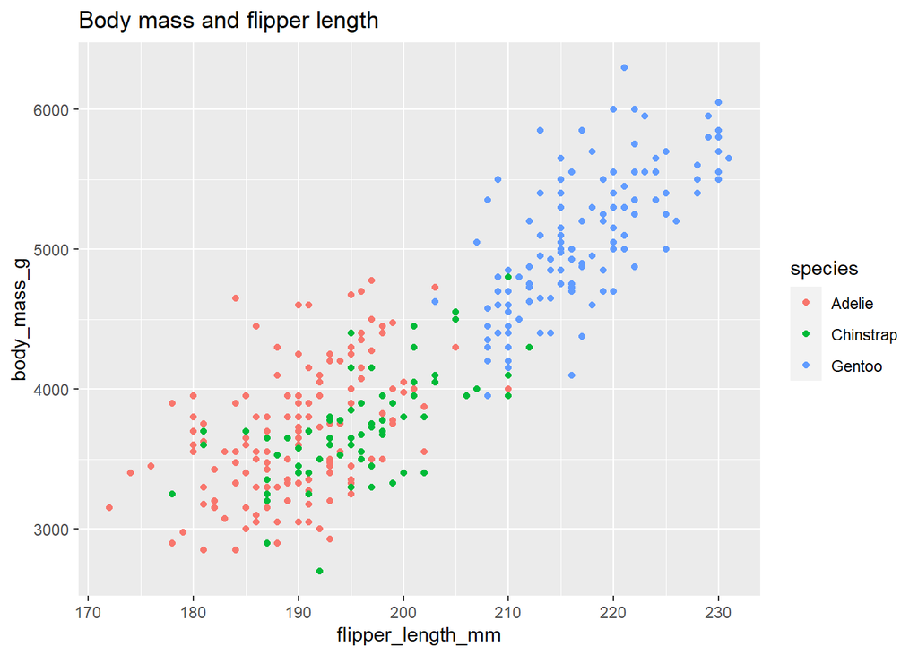

```r
ggplot(data = penguins) +
  geom_point(mapping = aes(x=flipper_length_mm, y=body_mass_g,color=species))+
  labs(title =  "Body mass and flipper length")
```

Let’s create graphs showing flipper lengths for each species separately.

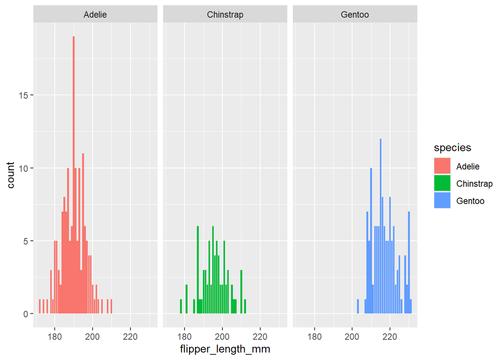

```r
ggplot(data = penguins) +
  geom_bar(mapping = aes(x=flipper_length_mm,fill=species)) + facet_wrap(~species)
```

We can also use geom_smooth to show relationship between body mass and flipper length.

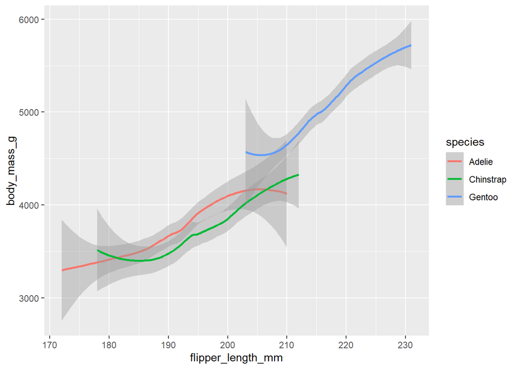

```r
ggplot(data = penguins) +
  geom_smooth(mapping = aes(x=flipper_length_mm, y=body_mass_g,color=species))
```

Plus, we can combine both together.

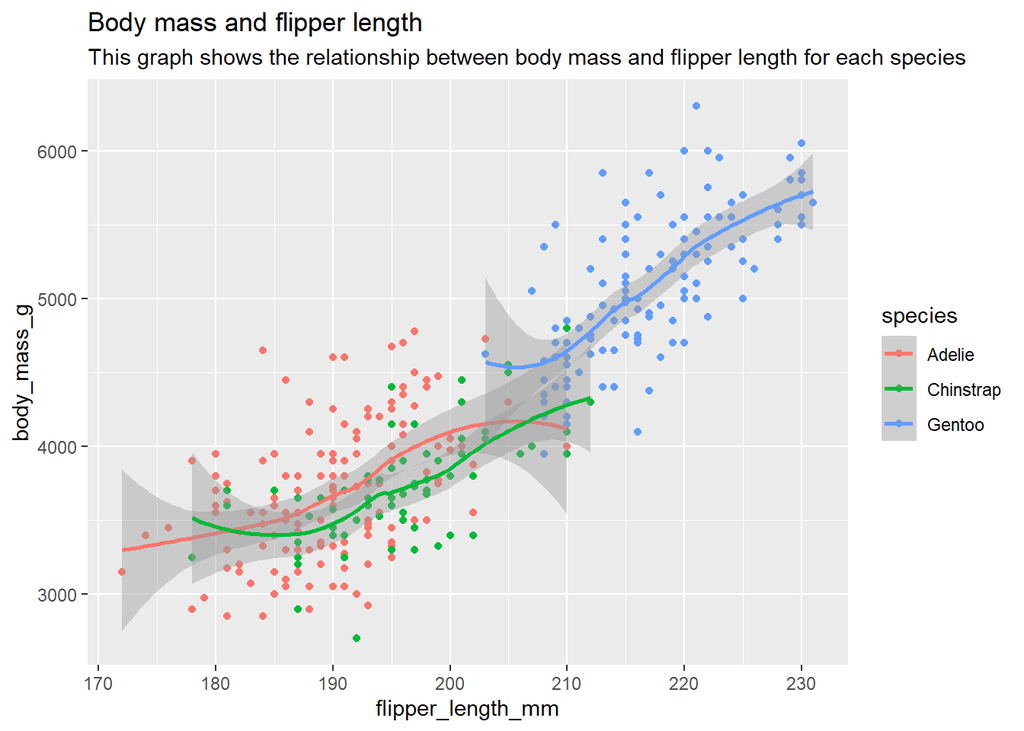

```r
ggplot(data = penguins) +
  geom_point(mapping = aes(x=flipper_length_mm, y=body_mass_g,color=species)) +
  geom_smooth(mapping = aes(x=flipper_length_mm, y=body_mass_g,color=species)) +
  labs(title =  "Body mass and flipper length",subtitle="This graph shows the relationship between body mass and flipper length for each species")
```

If we want to see how many species there are on each year:

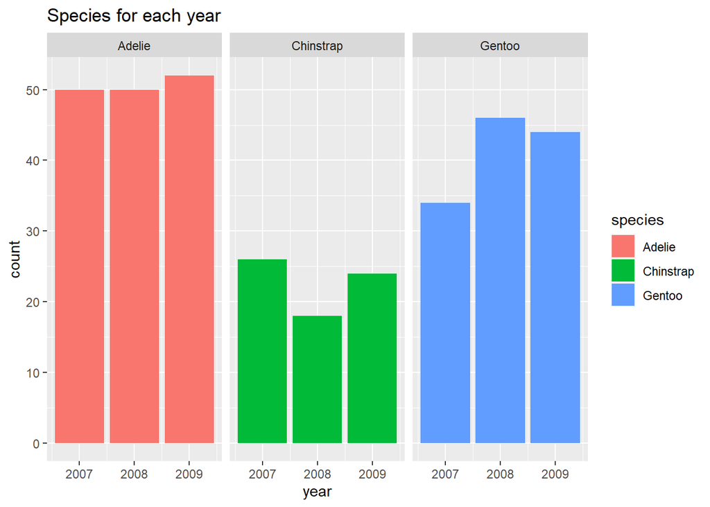

```r
ggplot(data = penguins) +
  geom_bar(mapping = aes(x=year,fill=species))+
  labs(title = "Species for each year") +
  facet_wrap(~species)
```

References : - https://doi.org/10.1371/journal.pone.0090081 Ecological Sexual Dimorphism and Environmental Variability within a Community of Antarctic Penguins (Genus Pygoscelis) Kristen B. Gorman ,Tony D. Williams,William R. Fraser -Google Data Analytics Professional Certificate, Data Analysis with R Programming.